# last_52525

Eitan Rosenfelder

6 8 2020

```r
#Calling the relevent libraries
library(dplyr)
```

```r
library(ggplot2)
library(readr)
```

#Q1

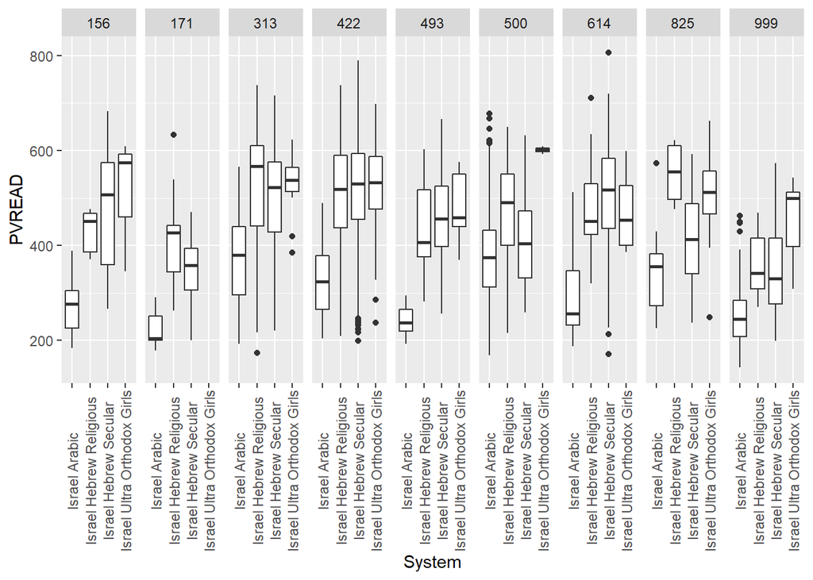

```r
pisa_data = read.csv("C:\\Users\\eitan\\Downloads\\pisa_israel_2018_fortargil.csv")
pisa_data[,"System"] <- as.factor(pisa_data[,"System"])
pisa_data[,"LANGN"] <- as.factor(pisa_data[,"LANGN"])
y <- data.frame(pisa_data[,2])
x <- data.frame(pisa_data[,-2])

#The two variables interplaying with the reading level
group_box_plot = ggplot(pisa_data, aes(x = System, y = PVREAD)) + geom_boxplot()

language_box_plot = ggplot(pisa_data, aes(x = as.factor(LANGN), y = PVREAD)) + geom_boxplot()

lang_group_box_plot = ggplot(pisa_data, aes(x=System, y=PVREAD)) + geom_boxplot() + facet_grid(~as.factor(LANGN)) + theme(axis.text.x  = element_text(angle=90, vjust=0.5))
lang_group_box_plot
```

We can see that if we take into account the language spoken at home and the cultural group the kid we will have very different grades expected.

#Q2 #a

```r
pisa_y = pisa_data[,2]
pisa_data = pisa_data[,-2]

#replacing the n.a.s by random numbers out of the observations we have
#with replacement, since I don't want to assume that the probability of the n.a.s
#is the same as the probability of the complete cases.

n_r <- nrow(pisa_data)
n_c <- ncol(pisa_data)
for (i in 1:n_c){
  a <- c(pisa_data[1:n_r,i])
  b <- complete.cases(a)
  a[is.na(a)] <- sample(b, size=sum(is.na(a)), replace=T)
  pisa_data[,i] <- a
}

sum(is.na(pisa_data))
```

```
## [1] 0
```

```r
#scaling the data
for (j in 3:ncol(pisa_data)){
  av <- mean(pisa_data[,j])
  st <- sd(pisa_data[,j])
  pisa_data[,j] <- (pisa_data[,j]-av)/st
}

sum(is.na(pisa_data))
```

```
## [1] 0
```

```r
x_num <- data.frame(pisa_data[,-c(1,2)])
cor(x_num,pisa_y, method = "spearman")
```

```
##                    [,1]
## AGE         0.008935881
## PAREDINT    0.289991538
## EFFORT1     0.139914790
## DURECEC     0.108420738
## ESCS        0.372410439
## JOYREAD     0.094723531
## DISCLIMA   -0.008014010
## TEACHSUP   -0.106892243
## CLSIZE      0.217982007
## STAFFSHORT -0.051174646
## EDUSHORT   -0.077695513
## TOTAT       0.126821732
## STRATIO    -0.037932976
```

The distance functions: Based on the box plot I did at the start, I saw that the biggest difference in systems was if arab or ultra orthodox girls, therefore the distance was set by that. I chose numbers up to 1 so that the system will mean something but not make a huge difference.

```r
group <- as.character(pisa_data[,1])

group_dist = function(a,b){
  if (a==b){
    return(0)
  } else if (any(c(a,b)=="Israel Arabic")){
    if (any(c(a,b)=="Israel Ultra Orthodox Girls")){
    return(1)}
    else {
      return(0.5)
  }} else if (any(c(a,b)=="Israel Ultra Orthodox Girls")){
    return(0.5)
  }
    else{
      return(0.25)
    }
}

dist_cat <- matrix(nrow = nrow(pisa_data),ncol = nrow(pisa_data))
for (i in 1:nrow(pisa_data)){
  for (j in 1:i){
    dist_cat[i,j] = dist_cat[j,i] = group_dist(group[i],group[j])
  }
}
```

Regarding language, we saw in the box plot that the language has some implication on the grades, but it is small, so I set a number smaller then 1, but big enough so that it will mean something.

```r
language <- as.character(pisa_data[,2])

language_dist = function(a,b){
  ifelse (identical(a,b),0,0.5)
}

dist_lan <- matrix(nrow = nrow(pisa_data),ncol = nrow(pisa_data))
for (i in 1:nrow(pisa_data)){
  for (j in 1:i){
    dist_lan[i,j] = dist_lan[j,i] = language_dist(language[i],language[j])
  }
}
```

The Metric I chose was Euclidean distance, since it implies well difference between students bases on different parameters. I scaled the data earlier so that the measuring scale won’t make a artificial difference. The distance matrix was calucalated by sweep so it will be quicker, since it wotks vectorialy.

```r
pisa_data_numeric <- as.matrix(pisa_data[,3:15])
pisa_data = as.data.frame.matrix(pisa_data)
names(pisa_data) = c("System", "LANGN", "AGE", "PAREDINT", "EFFORT1",
                     "DURECEC", "ESCS", "JOYREAD", "DISCLIMA","TEACHSUP", "CLSIZE","STAFFSHORT","EDUSHORT","TOTAT","STRATIO")

distance_num <- function(num_data){
    euc_distance <- list()
    for (i in 1:nrow(num_data)){
      euc_distance[[i]] = sweep(num_data, 2, num_data[i,], function(x,y) (x  - y)^2)
    }
    mat_dist <- matrix(nrow = nrow(num_data),ncol=1)
    for (j in 1:length(euc_distance)){
      dis_j <- rowSums(euc_distance[[j]])
      mat_dist <- cbind(mat_dist,dis_j)
    }
    mat_dist <- mat_dist[,-1]
    return(mat_dist)}
```

#b

```r
idx <- sample(x=1:nrow(pisa_data), size=.3*nrow(pisa_data))
train_x <- pisa_data[-idx,-2]
test_x <- pisa_data[idx,-2]
train_y <- as.numeric(pisa_data[-idx,2])
test_y <- as.numeric(pisa_data[idx,2])
combo <- as.matrix(rbind(train_x,test_x))
n_p <- nrow(train_x)
n_t <- nrow(combo)
system_school <- as.character(combo[,1])
combo <- combo[,-1]
dist_system <- matrix(nrow = length(system_school),ncol = length(system_school))
for (i in 1:length(system_school)){
  for (j in 1:i){
    dist_system[i,j] = dist_system[j,i] = group_dist(system_school[i],system_school[j])
  }
}
dist_system <- as.matrix(dist_system)
lang_school <- as.character(combo[,1])
combo <- combo[,-1]
dist_lang <- matrix(nrow = length(lang_school),ncol = length(lang_school))
for (i in 1:length(lang_school)){
  for (j in 1:i){
    dist_lang[i,j] = dist_lang[j,i] = language_dist(lang_school[i],lang_school[j])
  }
}
dist_lang <- as.matrix(dist_lang)
```

```r
stud <-c(3,4,5,6,7,8,13)-2
combo <- as.matrix(combo)
stud_dist_num <- distance_num(combo[,stud])
class_dist_num <- distance_num(combo[,-c(stud)])
class_dist <- class_dist_num + dist_system
stud_dist <- stud_dist_num + dist_lang

the_class_dist <- class_dist
rate <- 0.5
weight_dist = rate*stud_dist + (1-rate)*class_dist

test_weight_dist <- weight_dist[c(n_p:n_t),]

pred <- function(test_weight_dist,k,train_y){
  outlier = 3
  train_weight_dist = test_weight_dist[-outlier,-outlier]
  top <- head(sort(train_y[train_weight_dist], decreasing=FALSE), k)
return(top)}

ans <- as.numeric(pred(test_weight_dist,k=10,train_y))

expected <- mean(ans)

test_y <- as.numeric(test_y)
mistake_mse <- mean((ans-test_y)^2)
```

#c

```r
sub_sample_cv_u <- function(pisa_data,y,idx){
  group <- as.character(pisa_data[,"System"])
  language <- as.character(pisa_data[,"LANGN"])
  group_ts <- group[idx]
  group_tr <- group[-idx]
  lan_tr <- language[-idx]
  lan_ts <- language[idx]
  pisa_data_numeric <- as.matrix(pisa_data[,-c(1,2)])
  trainx <- as.matrix(pisa_data_numeric[-idx,])
  testx <- as.matrix(pisa_data_numeric[idx,])
  test <- pisa_data[idx,]
  train_y <- y[-idx,]
  test_y <- y[idx,]


  stud <-c(3,4,5,6,7,8,13)-2
  student_dist <- distance_num(trainx[,stud])
  class_dist <- distance_num(trainx[,-stud])

  dist_lan_tr <- matrix(nrow = length(lan_tr),ncol = length(lan_tr))
  for (i in 1:length(lan_tr)){
    for (j in 1:i){
      dist_lan_tr[i,j] = dist_lan_tr[j,i] = language_dist(lan_tr[i],lan_tr[j])
    }
  }
  student_dist <- student_dist + dist_lan_tr

  dist_cat_tr <- matrix(nrow = length(group_tr),ncol = length(group_tr))
  for (i in 1:length(group_tr)){
    for (j in 1:i){
      dist_cat_tr[i,j] = dist_cat_tr[j,i] = group_dist(group_tr[i],group_tr[j])
    }
  }
  class_dist <- class_dist + dist_cat_tr

  expected <- matrix(nrow = 20,ncol = 50)
  rmse_a_k <- matrix(nrow = 20,ncol = 50)
  for (i in 1:20){
    a = i^(-1)
    dis_agg <- a*student_dist + (1-a)*class_dist
    agg <- rowSums(dis_agg)
    r_mistake_mse_k <- c()
    y_nearest <- c()
    for (k in 1:50){
      top_agg <- head(order(agg, decreasing = FALSE),k)
      y_nearest[k] <- mean(train_y[top_agg])
      r_mistake_mse_k[k] <- sqrt(mean((y_nearest[k]-test_y)^2))
    }
    expected <- rbind(expected,y_nearest)
    rmse_a_k <- rbind(rmse_a_k,r_mistake_mse_k)
  }
  expected <- expected[-c(1:20),]
  rmse_a_k <- rmse_a_k[-c(1:20),]

  s <- sd(test_y)
  colection <- list()
  colection[[1]] <- expected
  colection[[2]] <- rmse_a_k
  colection[[3]] <- s
return(colection)}
```

```r
cv_uniform <- function(pisa_data,y){
  full_cv_u <- list()
  for (l in 1:5){
    spliter <- sample(x=1:nrow(pisa_data), size=.2*nrow(pisa_data), replace = F)
    ans_u_cv <- sub_sample_cv_u(pisa_data,y,spliter)
    full_cv_u <- cbind(full_cv_u,ans_u_cv)
    print(l)}
  return(full_cv_u)}

full_cv_u <- cv_uniform(pisa_data,y)
```

```
## [1] 1
## [1] 2
## [1] 3
## [1] 4
## [1] 5
```

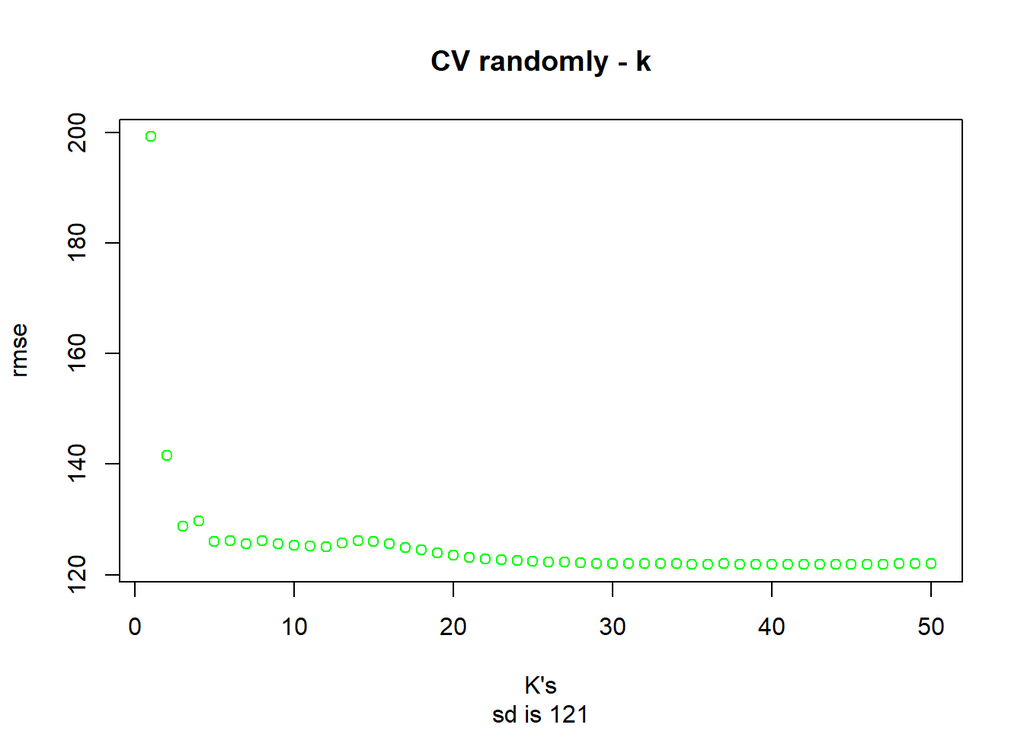

```
## integer(0)
```

```r
#plotting
#by k
m1k <- colMeans(full_cv_u[[2]])
m2k <- colMeans(full_cv_u[[5]])
m3k <- colMeans(full_cv_u[[8]])
m4k <- colMeans(full_cv_u[[11]])
m5k <- colMeans(full_cv_u[[14]])
Mk <- rbind(m1k,m2k)
Mk <- rbind(Mk,m3k)
Mk <- rbind(Mk,m4k)
Mk <- rbind(Mk,m5k)
cmk <- colMeans(Mk)
plot(cmk, col="green", xlab = "K's", ylab = "rmse") + title(main = "CV randomly - k", sub = "sd is 121")
```

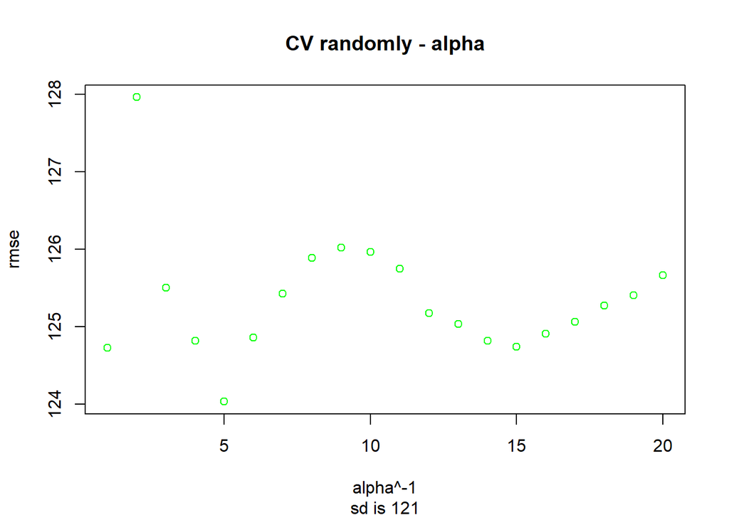

```
## integer(0)
```

```r
#by a
m1a <- rowMeans(full_cv_u[[2]])
m2a <- rowMeans(full_cv_u[[5]])
m3a <- rowMeans(full_cv_u[[8]])
m4a <- rowMeans(full_cv_u[[11]])
m5a <- rowMeans(full_cv_u[[14]])
Ma <- rbind(m1a,m2a)
Ma <- rbind(Ma,m3a)
Ma <- rbind(Ma,m4a)
Ma <- rbind(Ma,m5a)
cma <- colMeans(Ma)
plot(cma, col="green", xlab = "alpha^-1", ylab = "rmse") + title(main = "CV randomly - alpha", sub = "sd is 121")
```

```r
cv_classes <- function(class_dist,pisa_data, y){
  class_dist_col <- rowSums(class_dist)
  ord_cl <- order(class_dist_col, decreasing = FALSE)
  A <- head(ord_cl,1108)
  B <- ord_cl[1109:2218]
  C <- ord_cl[2219:3329]
  D <- ord_cl[3330:4437]
  E <- ord_cl[4438:5543]
  full_cv_byc <- list()
  for (l in 1:5){
    if (l==1){
      ans_c_cv <- sub_sample_cv_u(pisa_data, y,A)
      full_cv_byc <- cbind(full_cv_byc,ans_c_cv)
    }else if(l==2){
      ans_c_cv <- sub_sample_cv_u(pisa_data,y,B)
      full_cv_byc <- cbind(full_cv_byc,ans_c_cv)
    }else if(l==3){
      ans_c_cv <- sub_sample_cv_u(pisa_data,y,C)
      full_cv_byc <- cbind(full_cv_byc,ans_c_cv)
    } else if(l==4){
      ans_c_cv <- sub_sample_cv_u(pisa_data,y,D)
      full_cv_byc <- cbind(full_cv_byc,ans_c_cv)
    }else if(l==5){
      ans_c_cv <- sub_sample_cv_u(pisa_data,y,E)
      full_cv_byc <- cbind(full_cv_byc,ans_c_cv)
    }
    print(l)
  }
return(full_cv_byc)}

full_cv_byc <- cv_classes(the_class_dist,pisa_data,y)
```

```
## [1] 1
## [1] 2
## [1] 3
## [1] 4
## [1] 5
```

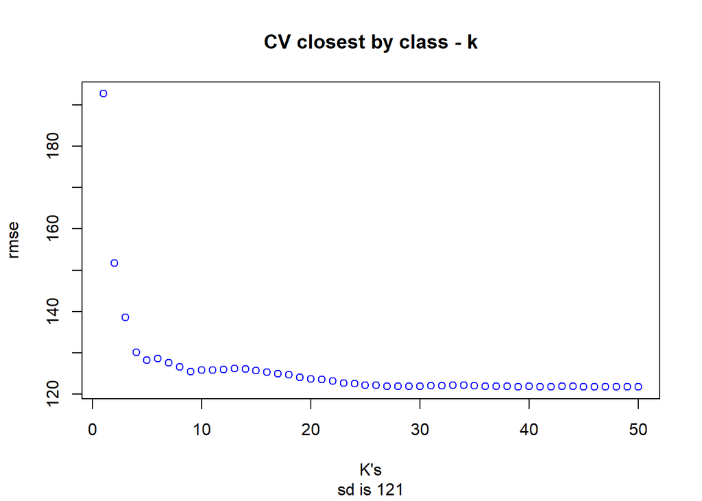

```
## integer(0)
```

```r
#plotting
#by k
m1k_c <- colMeans(full_cv_byc[[2]])
m2k_c <- colMeans(full_cv_byc[[5]])
m3k_c <- colMeans(full_cv_byc[[8]])
m4k_c <- colMeans(full_cv_byc[[11]])
m5k_c <- colMeans(full_cv_byc[[14]])
Mk_c <- rbind(m1k_c,m2k_c)
Mk_c <- rbind(Mk_c,m3k_c)
Mk_c <- rbind(Mk_c,m4k_c)
Mk_c <- rbind(Mk_c,m5k_c)
cmk_c <- colMeans(Mk_c)
plot(cmk_c, col="blue", xlab = "K's", ylab = "rmse") + title(main = "CV closest by class - k", sub = "sd is 121")
```

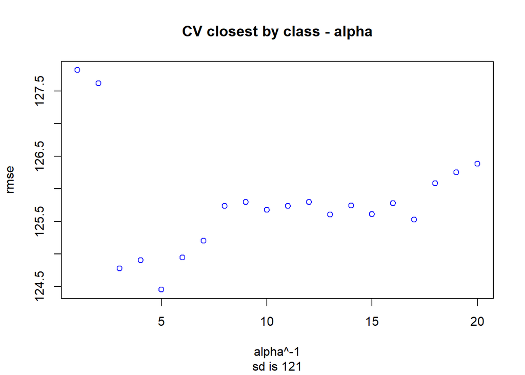

```
## integer(0)
```

```r
#by a
m1a_c <- rowMeans(full_cv_byc[[2]])
m2a_c <- rowMeans(full_cv_byc[[5]])
m3a_c <- rowMeans(full_cv_byc[[8]])
m4a_c <- rowMeans(full_cv_byc[[11]])
m5a_c <- rowMeans(full_cv_byc[[14]])
Ma_c <- rbind(m1a_c,m2a_c)
Ma_c <- rbind(Ma_c,m3a_c)
Ma_c <- rbind(Ma_c,m4a_c)
Ma_c <- rbind(Ma_c,m5a_c)
cma_c <- colMeans(Ma_c)
plot(cma_c, col="blue", xlab = "alpha^-1", ylab = "rmse") + title(main = "CV closest by class - alpha", sub = "sd is 121")
```

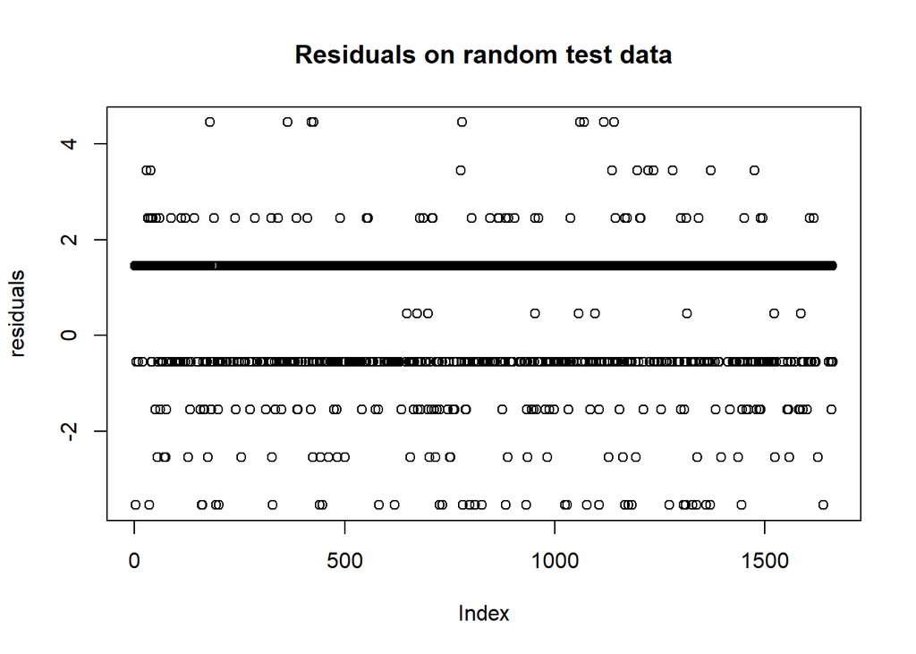

```
## integer(0)
```

```r
al <- 7^(-1)
K <- 12
dist_agg <- al*class_dist + (1-al)*stud_dist
top_agg_d <- head(order(dist_agg, decreasing = FALSE),K)/3881
y_nearest_d <- mean(train_y[top_agg_d])
residuals_d <- (y_nearest_d-test_y)
plot(residuals_d, ylab="residuals") + title(main="Residuals on random test data")
```

### Resources I used

#https://stackoverflow.com/questions/4862178/remove-rows-with-all-or-some-nas-missing-values-in-data-frame #https://ademos.people.uic.edu/Chapter11.html #https://stackoverflow.com/questions/14872783/how-do-i-show-all-boxplot-labels #Ariel Mantzura’s slides in the course of machine learning in economics. #https://stackoverflow.com/questions/1169248/test-if-a-vector-contains-a-given-element #https://statisticsglobe.com/r-sweep-function-example/#:<sub>:text=Basic%20R%20Syntax%3A&text=The%20sweep%20R%20function%20applies,by%20row%20or%20by%20column. #https://stackoverflow.com/questions/3692563/how-to-return-5-topmost-values-from-vector-in-r #https://data-flair.training/blogs/debugging-in-r-programming/ #https://stackoverflow.com/questions/21781596/refer-to-the-last-column-in-r #https://stackoverflow.com/questions/5171593/r-memory-management-cannot-allocate-vector-of-size-n-mb #https://stackoverflow.com/questions/3692563/how-to-return-5-topmost-values-from-vector-in-r #https://www.programmingr.com/r-error-messages/fixed-r-error-message-only-0s-may-be-mixed-with-negative-subscripts/#:</sub>:text=The%20reason%20this%20error%20occurs,the%20program%20what%20to%20exclude.&text=The%20reason%20for%20this%20error,from%20the%20resulting%20data%20structure. #https://stackoverflow.com/questions/5577727/is-there-an-r-function-for-finding-the-index-of-an-element-in-a-vector #https://stackoverflow.com/questions/6808621/find-the-index-position-of-the-first-non-na-value-in-an-r-vector #https://stackoverflow.com/questions/43166808/r-error-only-0s-may-be-mixed-with-negative-subscripts